# ICE Annina 10x sequencing analysis - Cross-cohort age prediction (original vs extended human data)

Author

Vladyslav Korobeynyk at Jessberger/Robinsonlab, UZH

Published

October 26, 2026

**Note**

**What this script does:** tests whether a glmnet age model trained on one human cohort generalizes to the other: the original human cohort used throughout the project ([Nature Genetics 2024](https://www.nature.com/articles/s41588-024-02050-9)) and the extended DLPFC lifespan cohort ([Synapse syn52396927](https://www.synapse.org/Synapse:syn52396927)). For IN and EN separately, a gaussian lasso age model is trained on all donors of one cohort and used to predict the age of every donor of the other cohort, in both directions. Performance is compared with the within-cohort cross-validation error of the same model, which is what the model achieves on unseen donors *from its own cohort*.

- **Like-for-like samples.** With `original_representation: "pseudobulk"`, the original cohort’s filtered single cells (`singlecell_sce_*_human.RDS` from `01_human_Processing.qmd`) are summed per patient, so both cohorts are donor-level pseudobulks. Otherwise the original metacells are used, and a drop in performance could come from the different sample type rather than from the donors.
- **Scaling.** As in the human/organoid notebooks, expression is z-scored per gene within each cohort, on the genes shared by both.
- **Age range.** With `restrict_test_to_train_age_range: true`, test donors outside the age range of the training cohort are dropped: a linear model cannot be expected to extrapolate (e.g. an adult-trained model to children).

**Important**

A cross-cohort drop in performance means the age signature does not transfer between the two datasets. That can reflect donor heterogeneity, but also differences in tissue dissection, protocol, sequencing and processing between the studies. These are not separable here, so the result should be phrased as “does not transfer between cohorts” rather than attributed to biological heterogeneity alone.

# Setup

```r
suppressMessages({
  library(scater)
  library(SingleCellExperiment)
  library(Matrix)
  library(dplyr)
  library(ggplot2)
  library(ggpubr)
  library(glmnet)
  library(caret)
  library(DT)
})
source(params$helper_functions_path)
dir.create(params$output_dir, recursive = TRUE, showWarnings = FALSE)
set.seed(1)
```

# Load data

```r
#' Original cohort: either summed per patient (pseudobulk) or the metacells as used before
load_original_cohort = function(celltype, representation) {
  if (representation == "pseudobulk") {
    sc = readRDS(file.path(params$original_dir, paste0("singlecell_sce_", celltype, "_human.RDS")))
    patient = factor(sc$Individual_ID)
    design = Matrix::sparse.model.matrix(~ 0 + patient)
    colnames(design) = levels(patient)
    counts_pb = counts(sc) %*% design                   # genes x patients, summed counts

    meta = as.data.frame(colData(sc))
    meta = meta[!duplicated(meta$Individual_ID), c("Individual_ID", "Age", "Sex", "Diagnosis", "Sample_Source")]
    rownames(meta) = meta$Individual_ID
    meta = meta[colnames(counts_pb), ]
    meta$n_cells = as.vector(table(patient)[colnames(counts_pb)])

    sce = SingleCellExperiment(assays = list(counts = counts_pb), colData = S4Vectors::DataFrame(meta))
    sce = logNormCounts(sce)
  } else if (representation == "metacell") {
    sce = readRDS(file.path(params$original_dir, paste0("metacell_sce_", celltype, "_human.RDS")))
  } else {
    stop("original_representation must be 'pseudobulk' or 'metacell'")
  }
  sce$Age = as.numeric(sce$Age)
  sce$cohort = "original"
  sce$batch_covariate = factor(sce$Sample_Source)
  sce[rowSums(counts(sce)) > 0, ]
}

#' Extended cohort: donor-level pseudobulks, same age filter as the other extended notebooks
load_extended_cohort = function(celltype, min_age, max_age) {
  sce = readRDS(file.path(params$extended_dir, paste0("pseudobulk_sce_", celltype, "_human_extended.RDS")))
  sce$Age = as.numeric(sce$Age)
  sce = sce[, !is.na(sce$Age) & sce$Age >= min_age & sce$Age < max_age]
  sce = sce[rowSums(counts(sce)) > 0, ]
  sce = logNormCounts(sce)
  sce$cohort = "extended"
  sce$batch_covariate = factor(sce$Brain_bank)
  sce
}
```

```r
cohorts = list(
  IN = list(original = load_original_cohort("IN", params$original_representation),
            extended = load_extended_cohort("IN", params$min_age, params$max_age)),
  EN = list(original = load_original_cohort("EN", params$original_representation),
            extended = load_extended_cohort("EN", params$min_age, params$max_age))
)

# samples, donors and age range per cohort
do.call(rbind, lapply(names(cohorts), function(ct) {
  do.call(rbind, lapply(names(cohorts[[ct]]), function(co) {
    sce = cohorts[[ct]][[co]]
    data.frame(celltype = ct, cohort = co, samples = ncol(sce),
               donors = length(unique(sce$Individual_ID)),
               min_age = min(sce$Age), median_age = median(sce$Age), max_age = max(sce$Age),
               genes = nrow(sce))
  }))
}))
```

| celltype | cohort | samples | donors | min_age | median_age | max_age | genes |
| --- | --- | --- | --- | --- | --- | --- | --- |
| IN | original | 96 | 96 | 31 | 68.5 | 79 | 17073 |
| IN | extended | 165 | 165 | 30 | 53.0 | 79 | 33230 |
| EN | original | 138 | 138 | 31 | 68.0 | 79 | 17062 |
| EN | extended | 165 | 165 | 30 | 53.0 | 79 | 33230 |

## Age distributions

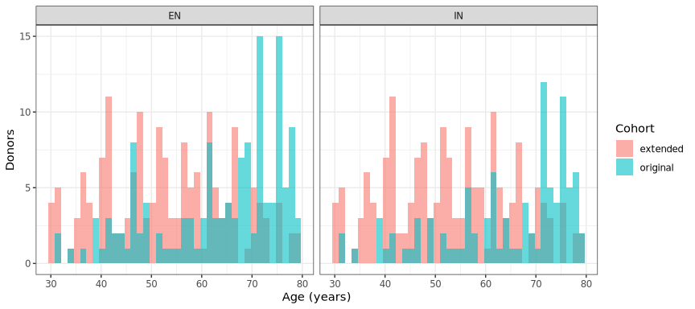

```r
age_df = do.call(rbind, lapply(names(cohorts), function(ct) {
  do.call(rbind, lapply(names(cohorts[[ct]]), function(co) {
    sce = cohorts[[ct]][[co]]
    d = unique(data.frame(Individual_ID = sce$Individual_ID, Age = sce$Age))
    data.frame(celltype = ct, cohort = co, Age = d$Age)
  }))
}))

ggplot(age_df, aes(x = Age, fill = cohort)) +
  geom_histogram(bins = 40, alpha = 0.6, position = "identity") +
  facet_wrap(~ celltype) +
  labs(x = "Age (years)", y = "Donors", fill = "Cohort") +
  theme_bw()
```

# Helper functions

```r
#' Keep genes with >= min_count counts in at least min_fraction of samples
filter_genes_min_expression = function(sce, min_count = params$min_gene_count,
                                       min_fraction = params$min_fraction_samples_expressing) {
  keep = rowSums(counts(sce) >= min_count) >= (min_fraction * ncol(sce))
  sce[keep, ]
}

#' Performance metrics of predicted vs true age
prediction_metrics = function(pred, truth) {
  data.frame(
    n = length(truth),
    pearson_r = cor(pred, truth, method = "pearson"),
    spearman_rho = cor(pred, truth, method = "spearman"),
    R2 = 1 - sum((truth - pred)^2) / sum((truth - mean(truth))^2),
    MAE = mean(abs(truth - pred)),
    RMSE = sqrt(mean((truth - pred)^2))
  )
}

#' Train a gaussian age model on all samples of one cohort, predict every sample of the other
cross_cohort_predict = function(train_sce, test_sce, celltype) {
  train_name = unique(train_sce$cohort); test_name = unique(test_sce$cohort)

  if (params$restrict_test_to_train_age_range) {
    test_sce = test_sce[, test_sce$Age >= min(train_sce$Age) & test_sce$Age <= max(train_sce$Age)]
  }

  # gene filter on the training cohort, then restrict both to shared genes
  train_sce = filter_genes_min_expression(train_sce)
  common_genes = intersect(rownames(train_sce), rownames(test_sce))
  train_sce = train_sce[common_genes, ]
  test_sce = test_sce[common_genes, ]

  # z-score per gene within each cohort; genes constant in the test cohort -> 0
  scaled_train = scale(t(as.matrix(logcounts(train_sce))))
  scaled_test = scale(t(as.matrix(logcounts(test_sce))))
  scaled_test[is.na(scaled_test)] = 0
  keep = colSums(is.na(scaled_train)) == 0
  scaled_train = scaled_train[, keep]; scaled_test = scaled_test[, keep]

  data = as.data.frame(scaled_train)
  data$label = train_sce$Age
  out = train_glmnet_model(df = data, model_family = "gaussian", n_times = 1, test = FALSE)

  preds = predict(out$cvfit, newx = scaled_test, s = "lambda.min", type = "response")[, 1]

  # within-cohort reference: CV error of the same model on the training cohort
  idx = out$cvfit$index["min", ]
  within_RMSE = sqrt(out$cvfit$cvm[idx])
  # metacells: average predictions per donor so every donor counts once
  # explicit dplyr:: so a masking summarise() (e.g. from plyr, if loaded in the session)
  # cannot silently drop the grouping columns
  pred_df = data.frame(Individual_ID = test_sce$Individual_ID, Age = test_sce$Age,
                       batch_covariate = test_sce$batch_covariate, pred = preds) %>%
    dplyr::group_by(Individual_ID, Age, batch_covariate) %>%
    dplyr::summarise(pred = mean(pred), .groups = "drop") %>%
    as.data.frame()
  stopifnot(all(c("Age", "pred") %in% colnames(pred_df)), nrow(pred_df) > 2)

  metrics = prediction_metrics(pred_df$pred, pred_df$Age)
  metrics = cbind(data.frame(celltype = celltype, train = train_name, test = test_name,
                             genes_used = ncol(scaled_train),
                             genes_selected = sum(coef(out$cvfit, s = "lambda.min")[-1] != 0),
                             within_cohort_CV_RMSE = within_RMSE),
                  metrics)

  p = ggplot(pred_df, aes(x = Age, y = pred)) +
    geom_abline(slope = 1, intercept = 0, linetype = "dotted", color = "gray50") +
    geom_point(aes(color = batch_covariate), alpha = 0.7) +
    geom_smooth(method = "lm", color = "black", linetype = "dashed") +
    labs(x = "True Age", y = "Predicted Age", color = "Sample source / brain bank",
         title = paste0(celltype, ": train ", train_name, " -> test ", test_name),
         subtitle = sprintf("r = %.2f | R² = %.2f | MAE = %.1f y | RMSE = %.1f y (within-cohort CV RMSE = %.1f y)",
                            metrics$pearson_r, metrics$R2, metrics$MAE, metrics$RMSE, within_RMSE)) +
    theme_bw()
  print(p)

  coefs = as.matrix(coef(out$cvfit, s = "lambda.min"))
  coefs = data.frame(gene = rownames(coefs), coef = coefs[, 1])
  coefs = coefs[coefs$gene != "(Intercept)" & coefs$coef != 0, ]
  write.table(coefs, file.path(params$output_dir,
              paste0("coefs_glmnet_", celltype, "_train_", train_name, ".txt")), row.names = FALSE)

  list(metrics = metrics, predictions = pred_df, coefs = coefs)
}
```

# Cross-cohort predictions

**IN: original -> extended**

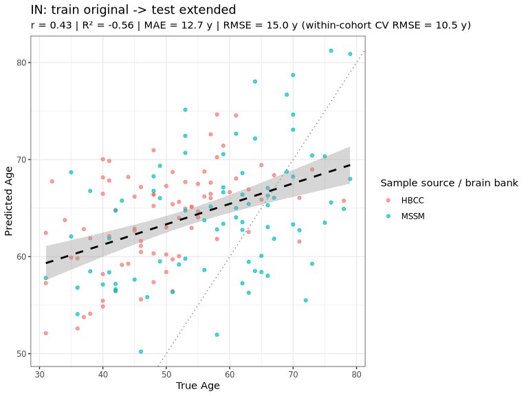

```r
res_IN_o2e = cross_cohort_predict(cohorts$IN$original, cohorts$IN$extended, "IN")
```

**IN: extended -> original**

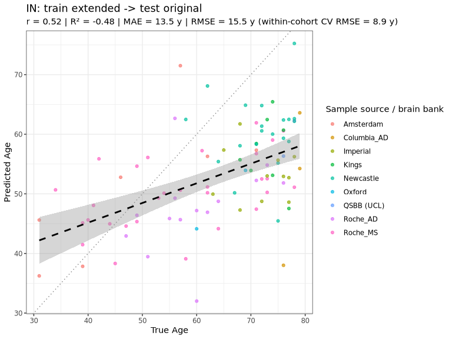

```r
res_IN_e2o = cross_cohort_predict(cohorts$IN$extended, cohorts$IN$original, "IN")
```

**EN: original -> extended**

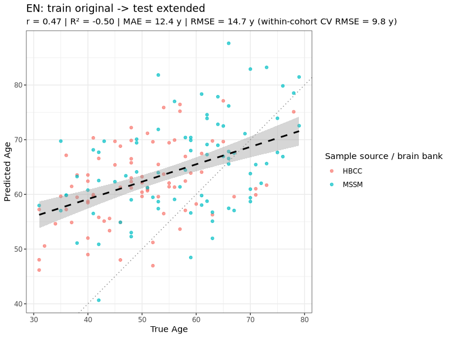

```r
res_EN_o2e = cross_cohort_predict(cohorts$EN$original, cohorts$EN$extended, "EN")
```

**EN: extended -> original**

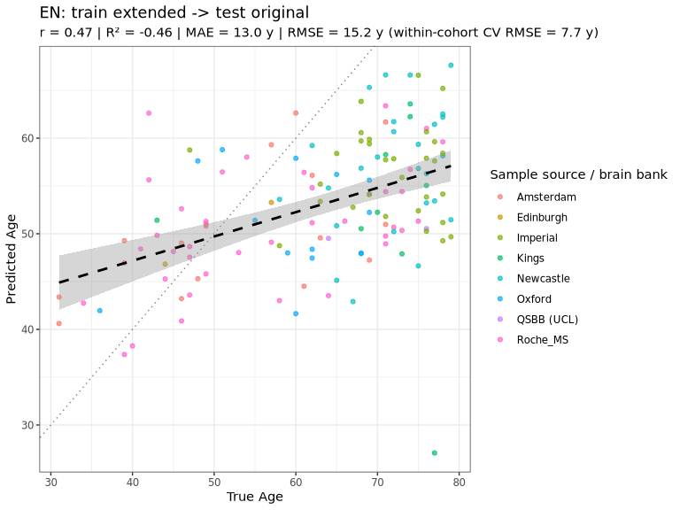

```r
res_EN_e2o = cross_cohort_predict(cohorts$EN$extended, cohorts$EN$original, "EN")
```

# Summary

```r
all_results = list(res_IN_o2e, res_IN_e2o, res_EN_o2e, res_EN_e2o)

summary_df = do.call(rbind, lapply(all_results, `[[`, "metrics"))
summary_df$direction = paste0(summary_df$train, " -> ", summary_df$test)
write.table(summary_df, file.path(params$output_dir, "cross_cohort_prediction_summary.txt"), row.names = FALSE)

summary_df %>%
  mutate(across(where(is.numeric), ~ round(.x, 2))) %>%
  datatable()
```

|  | celltype | train | test | genes_used | genes_selected | within_cohort_CV_RMSE | n | pearson_r | spearman_rho | R2 | MAE | RMSE | direction |
| --- | --- | --- | --- | --- | --- | --- | --- | --- | --- | --- | --- | --- | --- |
| 1 | IN | original | extended | 14110 | 39 | 10.54 | 161 | 0.43 | 0.39 | -0.56 | 12.74 | 15.04 | original -&gt; extended |
| 2 | IN | extended | original | 14864 | 145 | 8.89 | 96 | 0.52 | 0.52 | -0.48 | 13.53 | 15.5 | extended -&gt; original |
| 3 | EN | original | extended | 15407 | 144 | 9.79 | 161 | 0.47 | 0.42 | -0.5 | 12.4 | 14.66 | original -&gt; extended |
| 4 | EN | extended | original | 15529 | 171 | 7.75 | 138 | 0.47 | 0.47 | -0.46 | 12.97 | 15.24 | extended -&gt; original |

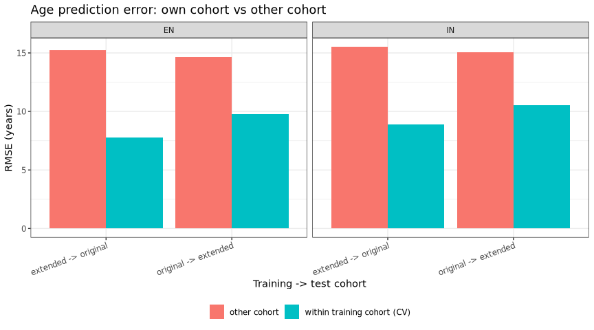

```r
# cross-cohort RMSE vs the same model's within-cohort CV RMSE
rmse_df = rbind(
  data.frame(celltype = summary_df$celltype, direction = summary_df$direction,
             type = "within training cohort (CV)", RMSE = summary_df$within_cohort_CV_RMSE),
  data.frame(celltype = summary_df$celltype, direction = summary_df$direction,
             type = "other cohort", RMSE = summary_df$RMSE)
)

ggplot(rmse_df, aes(x = direction, y = RMSE, fill = type)) +
  geom_col(position = "dodge") +
  facet_wrap(~ celltype) +
  labs(x = "Training -> test cohort", y = "RMSE (years)", fill = NULL,
       title = "Age prediction error: own cohort vs other cohort") +
  theme_bw() +
  theme(axis.text.x = element_text(angle = 20, hjust = 1), legend.position = "bottom")
```

## Overlap of selected genes

```r
#' Overlap of genes selected by the original- and extended-trained models, with a
#' hypergeometric test against the genes shared by both cohorts
gene_overlap = function(res_orig_trained, res_ext_trained, celltype) {
  g_orig = res_orig_trained$coefs$gene
  g_ext = res_ext_trained$coefs$gene
  universe = intersect(rownames(cohorts[[celltype]]$original), rownames(cohorts[[celltype]]$extended))
  shared = intersect(g_orig, g_ext)
  same_sign = sum(sign(res_orig_trained$coefs$coef[match(shared, g_orig)]) ==
                  sign(res_ext_trained$coefs$coef[match(shared, g_ext)]))
  data.frame(
    celltype = celltype,
    genes_original_model = length(g_orig),
    genes_extended_model = length(g_ext),
    shared = length(shared),
    shared_same_direction = same_sign,
    hypergeom_p = phyper(length(shared) - 1, length(g_orig), length(universe) - length(g_orig),
                         length(g_ext), lower.tail = FALSE)
  )
}

rbind(gene_overlap(res_IN_o2e, res_IN_e2o, "IN"),
      gene_overlap(res_EN_o2e, res_EN_e2o, "EN"))
```

| celltype | genes_original_model | genes_extended_model | shared | shared_same_direction | hypergeom_p |
| --- | --- | --- | --- | --- | --- |
| IN | 39 | 145 | 5 | 5 | 0.0000253 |
| EN | 144 | 171 | 7 | 6 | 0.0009024 |